# Job Placement Predictor

Mutua Kilai

[figure not shown]

# Description

## Problem Statement

The growing need of educated and talented individuals, especially in developing countries, recruiting fresh graduates is a routine practice in organizations. Conventional recruiting methods and selections processes can be prone to errors and in order to optimize the whole process, some innovative methods are needed.

## Objective

This project centers on building a predictive machine learning classification model that can predict the job placement status of individuals with historical data.

The application will tell whether a person will be placed or not.

## Dataset

The data source can be found [here](https://www.kaggle.com/datasets/ahsan81/job-placement-dataset)

The columns of the data set are described below:

- gender: Gender of the candidate
- ssc_percentage: Senior Secondary exams percentage (10th grade)
- ssc_board: Board of education for ssc exams
- hsc_percentage: Higher secondary exams percentage
- hsc_board: Board of education for hsc exams
- hsc_subject: Subject of study for hsc
- degree_percentage: Percentage of marks in undergrad degree
- undergrad_degree: Undergrad degree majors
- work_experience: Past work experience
- emp_test_percentage: Aptitude test percentage
- specialization: Postgrad degree majors
- mba_percent: Percentage of marks in MBA degree
- status: Status of placement. Placed/Not placed

## Skills

- Programming (R)
- Data Wrangling (dplyr)
- Data Analysis and visualization(ggplot2, tidyverse)
- Machine Learning (caret)
- Cloud deployment ()
- Backend
- Frontend

## Limitations

- The data set used was not large enough and is not up to date
- Improvement of the apps interface

## Open to collaboration

Still actively looking for deployment in a data science related role.

You can contact me through:

- [twitter](https://twitter.com/SamKMutua)
- [linkedin](https://www.linkedin.com/in/mutua-kilai-41b16115b/)

# Using R to Model

**Importing the data**

We use the base read.csv to import the data.

```r
Data <- read.csv("Job_Placement_Data.csv")

library(dplyr)
```

The first few rows of the data are given by

```r
knitr::kable(head(Data))
```

| gender | ssc_percentage | ssc_board | hsc_percentage | hsc_board | hsc_subject | degree_percentage | undergrad_degree | work_experience | emp_test_percentage | specialisation | mba_percent | status |
| --- | --- | --- | --- | --- | --- | --- | --- | --- | --- | --- | --- | --- |
| M | 67.00 | Others | 91.00 | Others | Commerce | 58.00 | Sci&Tech | No | 55.0 | Mkt&HR | 58.80 | Placed |
| M | 79.33 | Central | 78.33 | Others | Science | 77.48 | Sci&Tech | Yes | 86.5 | Mkt&Fin | 66.28 | Placed |
| M | 65.00 | Central | 68.00 | Central | Arts | 64.00 | Comm&Mgmt | No | 75.0 | Mkt&Fin | 57.80 | Placed |
| M | 56.00 | Central | 52.00 | Central | Science | 52.00 | Sci&Tech | No | 66.0 | Mkt&HR | 59.43 | Not Placed |
| M | 85.80 | Central | 73.60 | Central | Commerce | 73.30 | Comm&Mgmt | No | 96.8 | Mkt&Fin | 55.50 | Placed |
| M | 55.00 | Others | 49.80 | Others | Science | 67.25 | Sci&Tech | Yes | 55.0 | Mkt&Fin | 51.58 | Not Placed |

**Exploratory Data Analysis**

The visualization of the data is performed in order to have a feeling on the attributes of the data. The `ggplot2` package is used to do EDA.

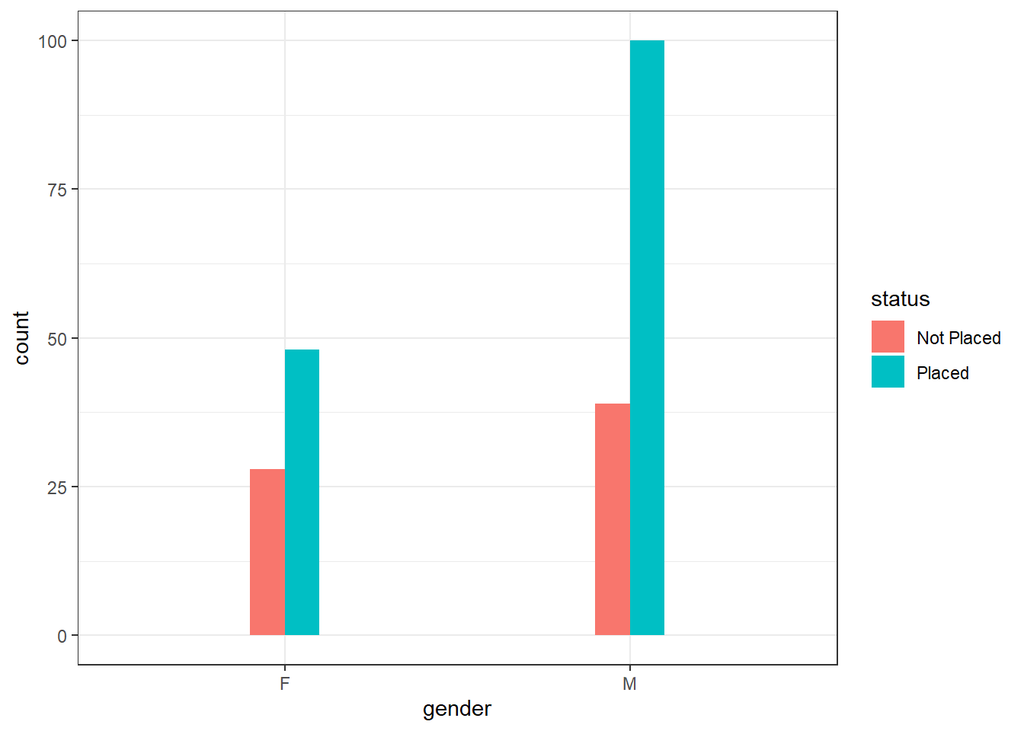

```r
library(ggplot2)

# visualization of status against gender

ggplot(Data, aes(x = gender, fill = status)) + geom_bar(position = "dodge", width = 0.2)+ theme_bw()
```

Aptitude test distribution across status.

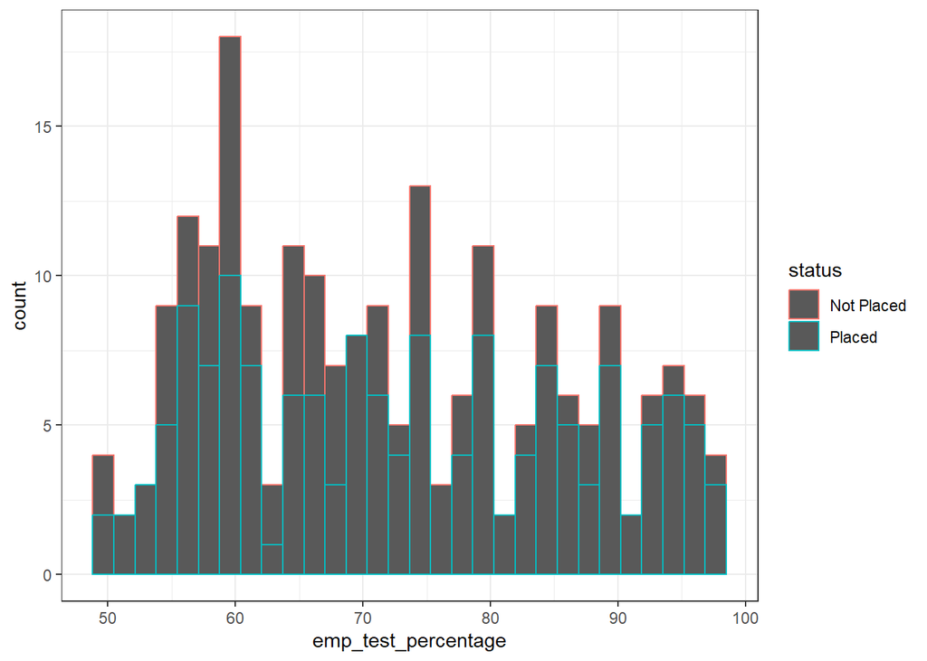

```r
ggplot(Data, aes(x = emp_test_percentage, color = status)) + geom_histogram(bins = 30) + theme_bw()
```

Work experience and status

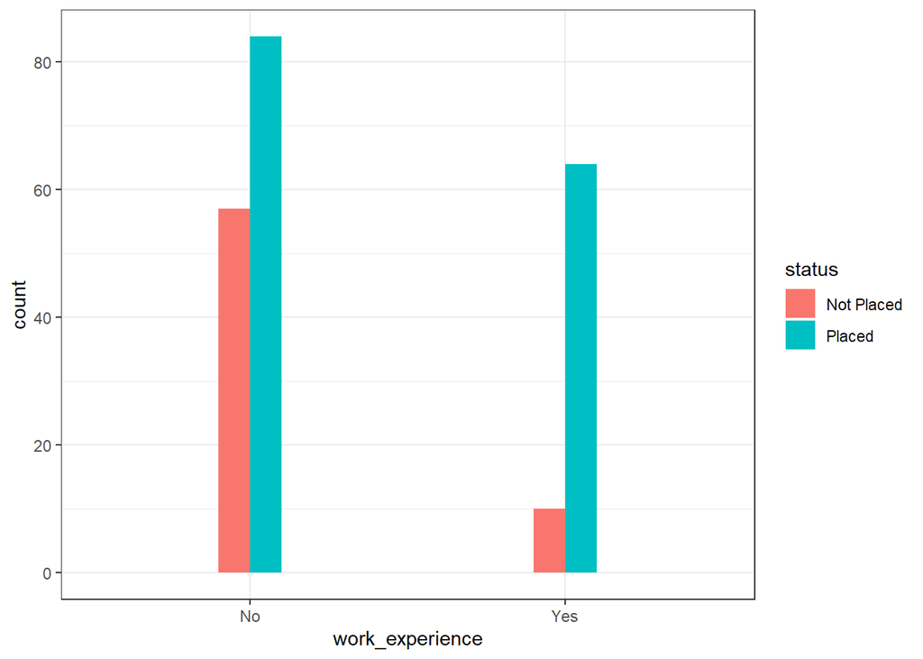

```r
ggplot(Data, aes(x = work_experience, fill = status)) + geom_bar(position = "dodge", width = 0.2) + theme_bw()
```

Relationship between mba percentage score and amplititude test score.

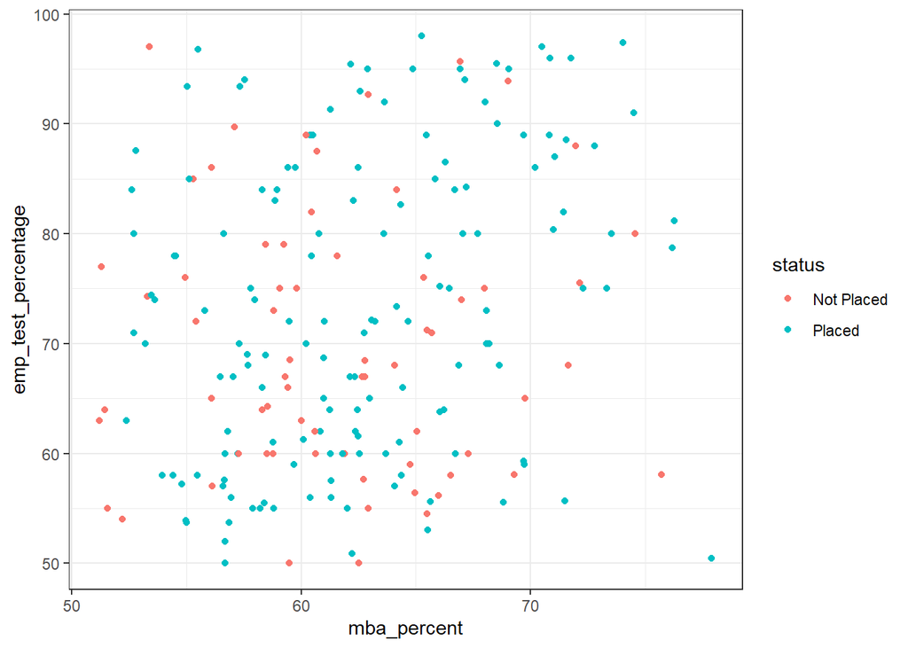

```r
ggplot(Data, aes(x = mba_percent, y = emp_test_percentage,color = status)) + geom_point()+ theme_bw()
```

Other visualizations can be done depending on what attribute you want to explore.

Now, we dig into the task of classification. We would like to predict if an applicant will be placed or not.

**Setting up the data**

We convert the characters to factors as follows.

```r
# convert characters to factors

Data <- Data %>%
  mutate_if(is.character, as.factor)
```

**Train Test split**

In this section we shall use the `caret` and `rsample` packages in R to do the tasks involved.

```r
library(caret) # for machine learning tasks

library(rsample) # for splitting data
```

We split the data into two sets, the *train* and *test* sets as follows. 70% of the data is used for training and 30% is used for testing.

```r
index <- initial_split(Data, prop = 0.7)

# training data

train <- training(index)

# testing data

test <- testing(index)
```

We now fit the following models to the data set and be able to select the best.

- Random Forest model
- Support Vector Machine classification model

We set a control for the data.

```r
# control

my_control <- trainControl(
  method = "cv",
  number = 10,
  repeats = 5
)

# metric

metric <- "Accuracy"
```

We fit the models highlighted before to our training data.

```r
set.seed(123)

# model random forest

rf_model <- train(
  status ~.,
  data = train,
  method = "ranger",
  metric = metric,
  trainControl = my_control
)


# model svm

svm_model <- train(
  status ~.,
  data = train,
  method = "svmRadial",
  metric = metric,
  trainControl = my_control
)
```

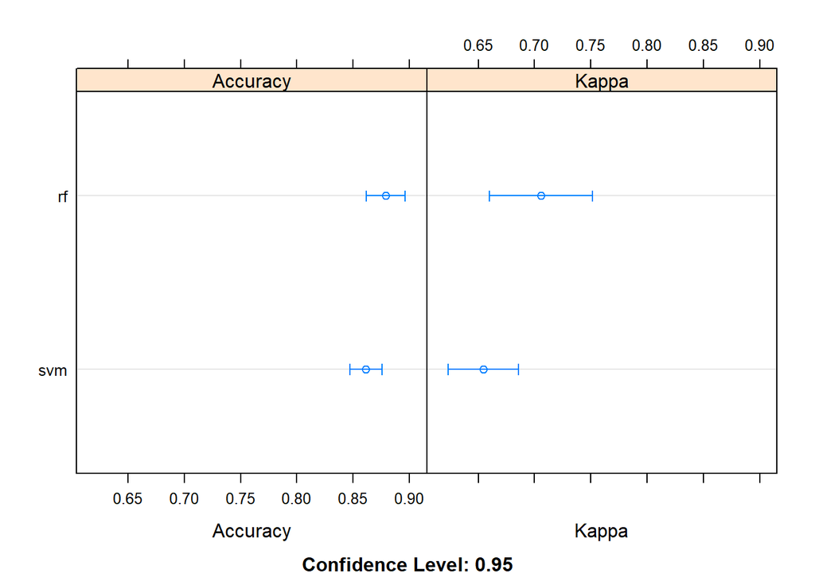

```r
set.seed(123)
results <- resamples(list(svm =svm_model, rf = rf_model))
dotplot(results)
```

We test the model to the test data in order to see the best model to use.

**Accuracy for Random Forest**

```r
# test data - random forest

pred_rf <- predict(rf_model, test[,-13])

# confusion matrix

confusionMatrix(pred_rf, test[["status"]], positive = "Placed")
```

```
## Confusion Matrix and Statistics
##
##             Reference
## Prediction   Not Placed Placed
##   Not Placed         10      3
##   Placed             11     41
##
##                Accuracy : 0.7846
##                  95% CI : (0.6651, 0.8769)
##     No Information Rate : 0.6769
##     P-Value [Acc > NIR] : 0.03894
##
##                   Kappa : 0.4531
##
##  Mcnemar's Test P-Value : 0.06137
##
##             Sensitivity : 0.9318
##             Specificity : 0.4762
##          Pos Pred Value : 0.7885
##          Neg Pred Value : 0.7692
##              Prevalence : 0.6769
##          Detection Rate : 0.6308
##    Detection Prevalence : 0.8000
##       Balanced Accuracy : 0.7040
##
##        'Positive' Class : Placed
##
```

**Accuracy for SVM model**

```r
pred_svm <- predict(svm_model, test[,-13])

# confusion matrix

confusionMatrix(pred_svm, test[["status"]])
```

```
## Confusion Matrix and Statistics
##
##             Reference
## Prediction   Not Placed Placed
##   Not Placed         11      1
##   Placed             10     43
##
##                Accuracy : 0.8308
##                  95% CI : (0.7173, 0.9124)
##     No Information Rate : 0.6769
##     P-Value [Acc > NIR] : 0.00417
##
##                   Kappa : 0.5643
##
##  Mcnemar's Test P-Value : 0.01586
##
##             Sensitivity : 0.5238
##             Specificity : 0.9773
##          Pos Pred Value : 0.9167
##          Neg Pred Value : 0.8113
##              Prevalence : 0.3231
##          Detection Rate : 0.1692
##    Detection Prevalence : 0.1846
##       Balanced Accuracy : 0.7505
##
##        'Positive' Class : Not Placed
##
```

Comparing SVM with linear radial and Random forest then we can conclude that SVM is the better model using the test data.

**The END**

To drop comments refer to my contacts shared at the beginning of the document.